# Temperature and nutrient effects on the larvae of three Hawaiian corals

Chris B Wall, with RM Kitchen, M Piscetta

2/10/2020

*Kitchen RM, Piscetta M, Lenz EA, de Souza MR, Schar D, Gates RD, Wall CB. Symbiont transmission and reproductive mode influence responses of three Hawaiian coral larvae to elevated temperature and nutrients. (2020) Coral Reefs*

## Synopsis

Corals are threatened by rising ocean temperatures and increased nutrient loading in coastal areas. The threats posed by elevated temperatures and nutrients for coral larvae – the early stages of the coral lifecycle – however are less certain, and the biology of corals in larval stages can differ considerably from that of adults. For instance, some species brood larvae with symbionts inherited from parents, others broadcast spawn egg-sperm bundles that receive endosymbionts from parents, while other egg-sperm bundles are aposymbontic and endosymbionts are obtained from the water column (i.e. horizontal transmittion).

The goal of this project was to understand how different temperature and nutrient concentrations affect the larvae of three Hawaiian reef coral taxa: *Lobactis scutaria* (broadcast spawner, aposymbiotic larvae), *Pocillopora acuta* (brooder, symbiotic larvae), and *Montipora capitata* (broadcast spawner, symbiotic larvae).

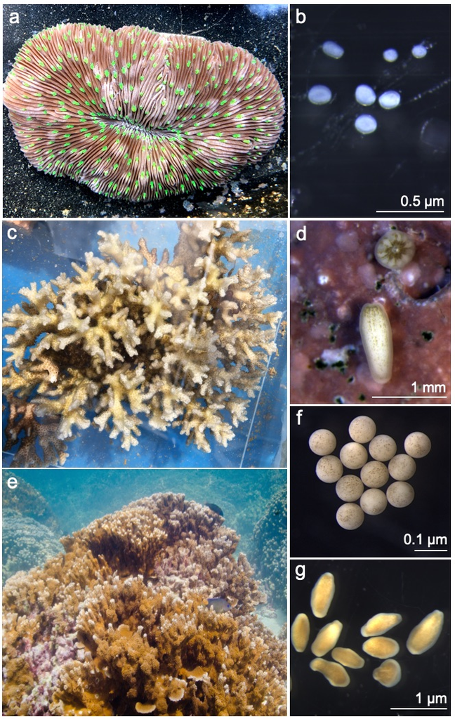

**Figure 1**. Adult and larvae of the Hawaiian corals (a,b) *Lobactis scutaria* and (c,d) *Pocillopora acuta*, with *Montipora capitata* (e) adult colonies, (f) eggs, and (g) planulae larvae. Metamorphosing P. acuta larvae (d, top right). L. scutaria and M. capitata are broadcast spawners, P. acuta is a brooder. L. scutaria larvae are initially aposymbiotic, while P. acuta and M. capitata inherit Symbiodiniaceae through vertical transmission. (PC: all authors, except d: R. Ritson-Williams

Temperature treatments oscillated with natural diel cycles at means of ca. 27°C and 29°C (*ambient and elevated temperatures*). Nutrient concentrations were elevated nitrate (5 μM NO<sub>3</sub><sup>-</sup>), elevated phosphate (1μM PO<sub>4</sub><sup>3-</sup>) and a combined elevated nitrate and phosphate treatment (+N+P). We evaluated effects of treatments after 4 or 5 days of exposure by assessing *(1) larval survivorship, (2) dark despiration rates, (3) symbiont cell densities, and (4) change in larval size.*

## Temperature treatments

Temperatures were variable according to natural cycles with *elevated temperature* (~29°C) at 1-2°C offset above ambient (~ 27°C).

```r
#Upload temperature data
temperature.data=read.csv("Data/temp data.csv")

#str(temperature.data)

#Subset by species
lobactis.temp=subset(temperature.data, Species=="Lobactis scutaria")
montipora.temp=subset(temperature.data, Species=="Montipora capitata")
pocillopora.temp=subset(temperature.data, Species=="Pocillopora acuta")
summary(lobactis.temp$Control_Temperature) #max=28.78, min=26.56, mean=27.37
summary(lobactis.temp$High_Temperature) #max=31.00, min=27.63, mean=29.17
summary(montipora.temp$Control_Temperature) #max=28.09, min=25.54, mean=26.97
summary(montipora.temp$High_Temperature) #max=31.84, min=27.46, mean=29.11
summary(pocillopora.temp$Control_Temperature) #max=28.25, min=26.43, mean=27.17
summary(pocillopora.temp$High_Temperature) #max=30.87,min=27.38, mean=28.72

############################
#plot the data for lobactis
l.long_temp<-lobactis.temp%>%
  select(Day,Control_Temperature,High_Temperature)%>%
  gather(Treatment,"temperature",-Day)

l.temp=ggplot(l.long_temp)+
  aes(Day,temperature,color=Treatment)+
  theme_classic(base_size=10)+
  labs(x="",y="")+
  theme(axis.title = element_text(size = 10, face="bold"))+
  theme(legend.position="none")+
  geom_hline(yintercept = 27.37, linetype="dashed", color="darkblue", size=0.6) +
  geom_hline(yintercept = 29.17, linetype="dashed", color="darkred", size=0.6) +
  ggtitle("L. scutaria") +
  theme(plot.title= element_text(face="italic"))+
  guides(col=guide_legend(ncol=2))+
  scale_x_continuous(breaks=seq(0,4,1),limits=c(0,5))+
  geom_line(aes(linetype=Treatment),size = 0.6)+
  scale_colour_manual(name="Treatment",values=c("cornflowerblue","coral"),
                      labels=c("Ambient","High"))+
  scale_linetype_manual(values=c("solid", "solid"),
                        labels=c("Ambient","High"))+
  scale_y_continuous(limits=c(25,33))

############################
#plot the data for montipora
m.long_temp<-montipora.temp%>%
  select(Day,Control_Temperature,High_Temperature)%>%
  gather(Treatment,"temperature",-Day)

############################
# plot for pocillopora
p.long_temp<-pocillopora.temp %>%
  select(Day,Control_Temperature,High_Temperature)%>%
  gather(Treatment,"temperature",-Day)

p.temp=ggplot(p.long_temp)+
  aes(Day,temperature,color=Treatment)+
  theme_classic()+
  labs(x="", y="Temperature (°C)")+
  theme(axis.title = element_text(size = 8, face="bold"))+
  theme(legend.position="none")+
  geom_hline(yintercept = 27.17, linetype="dashed", color="darkblue", size=0.6) +
  geom_hline(yintercept = 28.72, linetype="dashed", color="darkred", size=0.6) +
 ggtitle("P. acuta") +
  theme(plot.title= element_text(face="italic"))+
  guides(col=guide_legend(ncol=2))+
  scale_x_continuous(breaks=seq(0,5,1),limits=c(0,5))+
  geom_line(aes(linetype=Treatment),size = 0.6)+
  scale_colour_manual(name="Treatment",values=c("cornflowerblue","coral"),
                      labels=c("Ambient","High"))+
  scale_linetype_manual(values=c("solid", "solid"),
                        labels=c("Ambient","High"))+
  scale_y_continuous(limits=c(25,33))


m.temp<- ggplot(m.long_temp)+
  aes(Day,temperature,color=Treatment)+
  theme_classic(base_size=10)+
  labs(x="Day",y="")+
  theme(axis.title = element_text(size = 10, face="bold"))+
  theme(legend.position="none")+
  geom_hline(yintercept = 26.97, linetype="dashed", color="darkblue", size=0.6) +
  geom_hline(yintercept = 29.11, linetype="dashed", color="darkred", size=0.6) +
  ggtitle("M. capitata") +
  theme(plot.title= element_text(face="italic"))+
  guides(col=guide_legend(ncol=2))+
  scale_x_continuous(breaks=seq(0,5,1),limits=c(0,5))+
  geom_line(aes(linetype=Treatment),size = 0.6)+
  scale_colour_manual(name="Treatment",values=c("cornflowerblue","coral"),
                      labels=c("Ambient","High"))+
  scale_linetype_manual(values=c("solid", "solid"),
                        labels=c("Ambient","High"))+
  scale_y_continuous(limits=c(25,33))


c.temp.col=plot_grid(l.temp, p.temp, m.temp, labels=c("a","b","c"), nrow=3, align = "v", label_size = 10)
temp.legend=get_legend(l.temp+theme(legend.position = "top") +
                         theme(legend.title = element_text(size=10, face="bold")) +
                         theme(legend.text = element_text(size = 10, face="plain")))
```

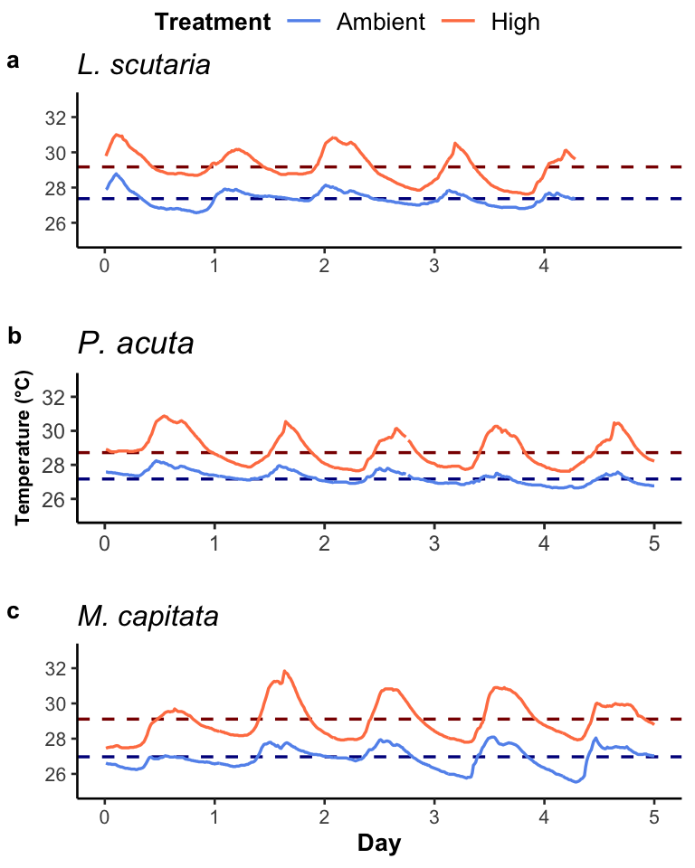

```r
##combined species panelled figure
plot_grid(temp.legend, c.temp.col, ncol=1, rel_heights = c(.2, 4))
```

```r
dev.copy(pdf, "figures/combined.temp.pdf", width = 6, height = 8)
dev.off()
```

## Biological responses

We measured larvae survivorship, dark respiration, symbiont densities, and change in size over the 4 or 5 day exposure to temperature-nutrient treatments.

### Survivorship

First the figure, then the complete stats, then final models.

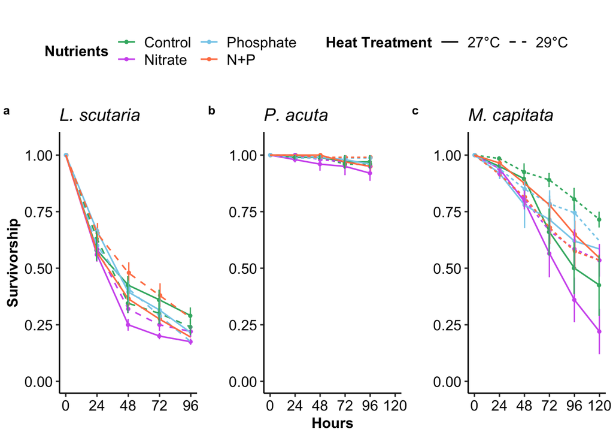

**Figure 3**. Survivorship for larvae of three coral species exposed to ambient (solid lines) and high (dashed lines) seawater temperatures and four nutrient concentrations of ambient (control) and elevated nitrate (+N) and phosphate (+P).

```r
detach("package:plyr", unload = TRUE) # do this here if get error, plyr and dplyr conflict

########################## Combined Daily Survivorship Figure ###################################

### upload data
# rename the N+P treatment
# set levels for treatment
daily.surv=read.csv("data/larval survivorship.csv")
levels(daily.surv$Nutrient.Treatment)[levels(daily.surv$Nutrient.Treatment)==
                                        "Nitrate and Phosphate"] <- "N+P"
daily.surv$Nutrient.Treatment=factor(daily.surv$Nutrient.Treatment,
                                       levels=c("Control", "Nitrate", "Phosphate", "N+P"))

# Lobactis
l.daily.surv=subset(subset(daily.surv, Species=="Lobactis scutaria"), Month=="2")

# Montipora
m.daily.surv=subset(subset(daily.surv, Species=="Montipora capitata"), Month=="2")

# Pocillopora
p.daily.surv=subset(subset(daily.surv, Species=="Pocillopora acuta"), Month=="2")


## Figures
#######################################
#######################################

l.long_surv = l.daily.surv%>%select(-Tube,-Species,-Month,-Final.Survivorship,-Treatment,-Day.5)%>%
  gather(Time,"Survivorship", -Heat.Treatment, -Nutrient.Treatment)%>%
  mutate(Percentage=Survivorship/40)%>%
  group_by(Heat.Treatment,Nutrient.Treatment,Time)%>%
  summarise(avg=mean(Percentage),sterr=std.error(Percentage))%>%
  mutate(Duration=as.numeric(case_when(Time=="Day.0"~"0",
                                       Time=="Day.1"~"24",
                                       Time=="Day.2"~"48",
                                       Time=="Day.3"~"72",
                                       Time=="Day.4"~"96")))%>%
  unite(Treatment,Heat.Treatment,Nutrient.Treatment,sep=" ", remove=FALSE)

####### lobactis.plot
l.long.surv=ggplot(l.long_surv)+ aes(Duration,avg,color=Nutrient.Treatment, linetype=Heat.Treatment)+
  geom_point(size=1, position=position_dodge(1))+
  geom_line(size=0.6)+
  geom_errorbar(aes(ymin=avg-sterr, ymax=avg+sterr, width=0),position=position_dodge(1), lty=1)+
  theme_classic(base_size=12)+
  labs(x="",y="Survivorship")+
  guides(col=guide_legend(ncol=2))+
  scale_colour_manual(name="Nutrients", values=c("mediumseagreen","mediumorchid2","skyblue", "coral"))+
  scale_linetype_manual(name="Heat Treatment", values = c(1, 2),
                        labels = c("27°C", "29°C")) +
  scale_x_continuous(breaks=seq(0,96,24),limits=c(0,96))+
  scale_y_continuous(limits=c(0,1.05))+
  ggtitle("L. scutaria") +
  theme(plot.title= element_text(face="italic"),
        legend.key.height=unit(0.5, "cm"),
        text = element_text(size = 12),
        axis.text = element_text(size = 12, color="black"),
        axis.title = element_text(size = 12, face="bold"),
        legend.title = element_text(size = 12, face="bold"),
        legend.text = element_text(size = 12, color="black"),
        legend.position="none")


####
p.long_surv = p.daily.surv%>%select(-Tube,-Species,-Month,-Final.Survivorship,-Treatment,-Day.5)%>%
  gather(Time,"Survivorship", -Heat.Treatment, -Nutrient.Treatment)%>%
  mutate(Percentage=Survivorship/20)%>%
  group_by(Heat.Treatment,Nutrient.Treatment,Time)%>%
  summarise(avg=mean(Percentage),sterr=std.error(Percentage))%>%
  mutate(Duration=as.numeric(case_when(Time=="Day.0"~"0",
                                       Time=="Day.1"~"24",
                                       Time=="Day.2"~"48",
                                       Time=="Day.3"~"72",
                                       Time=="Day.4"~"96",
                                       Time=="Day.5"~"120")))%>%
  unite(Treatment,Heat.Treatment,Nutrient.Treatment,sep=" ", remove=FALSE)

p.long.surv=ggplot(p.long_surv)+aes(Duration,avg,color=Nutrient.Treatment, linetype=Heat.Treatment)+
  geom_point(size=1, position=position_dodge(1))+
  geom_line(size=0.6) +
  geom_errorbar(aes(ymin=avg-sterr, ymax=avg+sterr, width=0),position=position_dodge(1), lty=1)+
  theme_classic(base_size=12)+
  labs(x="Hours",y="")+
  guides(col=guide_legend(ncol=2))+
  scale_colour_manual(name="Nutrients", values=c("mediumseagreen","mediumorchid2","skyblue", "coral"))+
  scale_x_continuous(breaks=seq(0,120,24),limits=c(0,120))+
  scale_y_continuous(limits=c(0,1.05))+
  theme(legend.key.height=unit(0.5, "cm"),
        text = element_text(size = 12),
        axis.text = element_text(size = 12, color="black"),
        axis.title = element_text(size = 12, face="bold"),
        legend.title = element_text(size = 12, face="bold"),
        legend.text = element_text(size = 12, color="black"),
        legend.position="none")+
  ggtitle("P. acuta") +
  theme(plot.title= element_text(face="italic"))

####### montipora.plot
m.long_surv = m.daily.surv%>%select(-Tube,-Species,-Month,-Final.Survivorship,-Treatment)%>%
  gather(Time,"Survivorship", -Heat.Treatment, -Nutrient.Treatment)%>%
  mutate(Percentage=Survivorship/40)%>%
  group_by(Heat.Treatment,Nutrient.Treatment,Time)%>%
  summarise(avg=mean(Percentage),sterr=std.error(Percentage))%>%
  mutate(Duration=as.numeric(case_when(Time=="Day.0"~"0",
                                       Time=="Day.1"~"24",
                                       Time=="Day.2"~"48",
                                       Time=="Day.3"~"72",
                                       Time=="Day.4"~"96",
                                       Time=="Day.5"~"120")))%>%
  unite(Treatment,Heat.Treatment,Nutrient.Treatment,sep=" ", remove=FALSE)

####
m.long.surv=ggplot(m.long_surv)+aes(Duration,avg,color=Nutrient.Treatment, linetype=Heat.Treatment)+
  geom_point(size=1, position=position_dodge(1))+
  geom_line(size=0.6)+
  geom_errorbar(aes(ymin=avg-sterr, ymax=avg+sterr, width=0),position=position_dodge(1), lty=1)+
  theme_classic(base_size=12)+
  labs(x="",y="")+
  guides(col=guide_legend(ncol=2))+
  scale_colour_manual(name="Nutrients", values=c("mediumseagreen","mediumorchid2","skyblue", "coral"))+
  scale_x_continuous(breaks=seq(0,120,24),limits=c(0,120))+
  scale_y_continuous(limits=c(0,1.05))+
  theme(legend.key.height=unit(0.5, "cm"),
        text = element_text(size = 12),
        axis.text = element_text(size = 12, color="black"),
        axis.title = element_text(size = 12, face="bold"),
        legend.title = element_text(size = 12, face="bold"),
        legend.text = element_text(size = 12, color="black"),
        legend.position="none")+
  ggtitle("M. capitata") +
  theme(plot.title= element_text(face="italic"))


######## Figure
total.surv.row=plot_grid(l.long.surv, p.long.surv, m.long.surv,  labels=c("a","b","c"),ncol = 3, align = "h", label_size = 10)
fin.surv.legend=get_legend(l.long.surv+theme(legend.position = "top"))
fin.surv=plot_grid(fin.surv.legend, total.surv.row, ncol=1, rel_heights = c(.3,1))

##Arrange figures with cowplot
fin.surv
```

```r
dev.copy(pdf,"figures/combined.daily.survivorship.pdf", width = 8, height = 4)
dev.off()
```

The full model testing and assumptions of statistical tests (output not shown).

```r
#######################################
#### Statistics
#######################################
l.format_surv<-l.daily.surv%>%select(-Month,-Final.Survivorship,-Treatment,-Day.5)%>%
  gather(Time,"Survivorship",-Nutrient.Treatment,-Heat.Treatment,-Day.0,-Tube,-Species)%>%
  mutate(Lost=Day.0-Survivorship)%>%
  group_by(Species,Heat.Treatment,Nutrient.Treatment,Time,Tube)%>%
  summarise(surv=sum(Survivorship),lost=sum(Lost))%>%
  mutate(Duration=as.numeric(case_when(Time=="Day.0"~"0",
                                       Time=="Day.1"~"24",
                                       Time=="Day.2"~"48",
                                       Time=="Day.3"~"72",
                                       Time=="Day.4"~"96")))%>%
  unite(Treatment,Heat.Treatment,Nutrient.Treatment,sep="_",remove = FALSE)

m.format_surv<-m.daily.surv%>%select(-Month,-Final.Survivorship,-Treatment)%>%
  gather(Time,"Survivorship",-Nutrient.Treatment,-Heat.Treatment,-Day.0,-Tube,-Species)%>%
  mutate(Lost=Day.0-Survivorship)%>%
  group_by(Species,Heat.Treatment,Nutrient.Treatment,Time,Tube)%>%
  summarise(surv=sum(Survivorship),lost=sum(Lost))%>%
  mutate(Duration=as.numeric(case_when(Time=="Day.0"~"0",
                                       Time=="Day.1"~"24",
                                       Time=="Day.2"~"48",
                                       Time=="Day.3"~"72",
                                       Time=="Day.4"~"96",
                                       Time=="Day.5"~"120")))%>%
  unite(Treatment,Heat.Treatment,Nutrient.Treatment,sep="_",remove = FALSE)

p.format_surv<-p.daily.surv%>%select(-Month,-Final.Survivorship,-Treatment)%>%
  gather(Time,"Survivorship",-Nutrient.Treatment,-Heat.Treatment,-Day.0,-Tube,-Species)%>%
  mutate(Lost=Day.0-Survivorship)%>%
  group_by(Species,Heat.Treatment,Nutrient.Treatment,Time,Tube)%>%
  summarise(surv=sum(Survivorship),lost=sum(Lost))%>%
  mutate(Duration=as.numeric(case_when(Time=="Day.0"~"0",
                                       Time=="Day.1"~"24",
                                       Time=="Day.2"~"48",
                                       Time=="Day.3"~"72",
                                       Time=="Day.4"~"96",
                                       Time=="Day.5"~"120")))%>%
  unite(Treatment,Heat.Treatment,Nutrient.Treatment,sep="_",remove = FALSE)

unfold<-function(x,lost_colname,surv_colname){
  lost_expanded<-x[rep(row.names(x), x[[lost_colname]]), 1:ncol(x)]
  lost_final<-lost_expanded%>%mutate(outcome=1)
  surv_expanded<-x[rep(row.names(x), x[[surv_colname]]), 1:ncol(x)]
  surv_final<-surv_expanded %>% mutate(outcome=0)
  rbind(lost_final,surv_final)}

l.cox_data<-unfold(l.format_surv,"lost","surv")
m.cox_data<-unfold(m.format_surv, "lost","surv")
p.cox_data<-unfold(p.format_surv, "lost","surv")

c.cox_data=rbind(l.cox_data, m.cox_data, p.cox_data)

#######################################
# surviorship dataframes l.cox_data, m.cox_data, p.cox_data
#######################################
#######################################


# Lobactis models
#####
l.surv.data<-l.cox_data
l.surv.data<-as.data.frame(l.surv.data) # make dataframe

l.cox_model<-coxph(Surv(Duration,outcome)~Heat.Treatment*Nutrient.Treatment+(1|Tube), data=l.surv.data)
l.cox_model1<-coxph(Surv(Duration,outcome)~Heat.Treatment*Nutrient.Treatment, data=l.surv.data)

anova(l.cox_model, l.cox_model1) #not different

#testing Cox hazards assumptions via scaled Schoenfeld residuals
test.ph.f <- cox.zph(l.cox_model1); test.ph.f
ggcoxzph(test.ph.f)

#Martingale residuals testing for influential observations
ggcoxdiagnostics(l.cox_model1, type = "dfbeta",
                 linear.predictions = FALSE, ggtheme = theme_bw())


### ANOVA
anova(l.cox_model1) # effects of nutrients, effects of Nut:Treat

### Post hocs

# test for nutrient effects
pairwise_survdiff(Surv(Duration,outcome)~Nutrient.Treatment, data=l.surv.data) #Treatment here is the orthogonal interaction
# - Control different from all others, Nitrate differs from control, from phosphate, and from N+P

# test for nut:heat effects
pairwise_survdiff(Surv(Duration,outcome)~Treatment, data=l.surv.data) #Treatment here is the orthogonal interaction

#- driven by changes in two treatments
# - N:Ambient --- differ from Cont:Amb, Cont:Heat, N+P:Heat, P:Amb
# - N+P:Heat --- differ from N+P:Amb, N:Amb, N:Heat, P:Heat

# test plot with global p value
ggsurvplot(survfit(Surv(Duration,outcome)~Nutrient.Treatment, data=l.surv.data), pval=TRUE) # showing global p value

# test plot with global p value
ggsurvplot(survfit(Surv(Duration,outcome)~Treatment, data=l.surv.data), pval=TRUE) # showing global p value


#######################################
#######################################
# Pocillopora models
####

p.surv.data<-p.cox_data
p.surv.data<-as.data.frame(p.surv.data) # make dataframe

p.cox_model<-coxph(Surv(Duration,outcome)~Heat.Treatment*Nutrient.Treatment+(1|Tube), data=p.surv.data)
p.cox_model1<-coxph(Surv(Duration,outcome)~Heat.Treatment*Nutrient.Treatment, data=p.surv.data)

anova(p.cox_model, p.cox_model1) #not different

#testing Cox hazards assumptions via scaled Schoenfeld residuals
test.ph.p <- cox.zph(p.cox_model1); test.ph.p
ggcoxzph(test.ph.p)

#Martingale residuals testing for influential observations
ggcoxdiagnostics(p.cox_model1, type = "dfbeta",
                 linear.predictions = FALSE, ggtheme = theme_bw())

### ANOVA
anova(p.cox_model1) # effects of heat, effects of nutrients, no interaction

### Post hocs

# test for nutrient effects
pairwise_survdiff(Surv(Duration,outcome)~Nutrient.Treatment, data=p.surv.data) #Treatment here is the orthogonal interaction
# - Nitrate differs  from phosphate, and from N+P (almost from control but not quite)

# test for heat effects
pairwise_survdiff(Surv(Duration,outcome)~Heat.Treatment, data=p.surv.data)

#- effects very small
# -Nutrients --- Nitrate starts to harm survivorship at end
# -Heat --- slightly lover (but not really) in ambient

# test plot with global p value for nutrients
poc.nut<-ggsurvplot(survfit(Surv(Duration,outcome)~Nutrient.Treatment, data=p.surv.data), pval=TRUE);poc.nut # showing global p value

# test plot with global p value for temp
poc.temp<-ggsurvplot(survfit(Surv(Duration,outcome)~Heat.Treatment, data=p.surv.data), pval=TRUE);poc.temp # showing global p value


#######################################
#######################################
# Montipora models
####

m.surv.data<-m.cox_data
m.surv.data<-as.data.frame(m.surv.data) # make dataframe

m.cox_model<-coxph(Surv(Duration,outcome)~Heat.Treatment*Nutrient.Treatment+(1|Tube), data=m.surv.data)
m.cox_model1<-coxph(Surv(Duration,outcome)~Heat.Treatment*Nutrient.Treatment, data=m.surv.data)

anova(m.cox_model, m.cox_model1) #not different

#testing Cox hazards assumptions via scaled Schoenfeld residuals
test.ph.m <- cox.zph(m.cox_model1); test.ph.m
#ggcoxzph(test.ph.m)

#Martingale residuals testing for influential observations
ggcoxdiagnostics(m.cox_model1, type = "dfbeta",
                 linear.predictions = FALSE, ggtheme = theme_bw())

### ANOVA
anova(m.cox_model1) # effects of nutrients, effects of temp, and interaction

### Post hocs

# test for orthogonal effects
pairwise_survdiff(Surv(Duration,outcome)~Treatment, data=m.surv.data) #Treatment here is the orthogonal interaction

# - relative to control:Amb,  heat increased survivorship
# - lowest survivorship in nitrate+amb (different from all other treatments, but only slightly more than control)
# - highest survivorship in control+heat
# - survivorship > ambient:control in Control:heat, NP:amb, P:heat
# - survivorship < ambient:heat in all treatments

#some plots
# test for heat effects
pairwise_survdiff(Surv(Duration,outcome)~Heat.Treatment, data=m.surv.data)
# - Temp: survivorship not harmed by higher temp (actually highe in warmer water)

# test for nutrient effects
pairwise_survdiff(Surv(Duration,outcome)~Nutrient.Treatment, data=m.surv.data)
# - Nutrients: Nitrate differ than control, phosphate, N+P. ALSO, P different from control

# test plot with global p value for combined temp
ggsurvplot(survfit(Surv(Duration,outcome)~Treatment, data=m.surv.data), pval=TRUE) # showing global p value
```

**The final models for survivorship results for *L. scutaria*, *P. acuta*, and *M. capitata*.**

```r
anova(l.cox_model1)
```

```
## Analysis of Deviance Table
##  Cox model: response is Surv(Duration, outcome)
## Terms added sequentially (first to last)
##
##                                   loglik   Chisq Df Pr(>|Chi|)
## NULL                              -31198
## Heat.Treatment                    -31197  1.5832  1  0.2082959
## Nutrient.Treatment                -31189 17.2275  3  0.0006345 ***
## Heat.Treatment:Nutrient.Treatment -31182 14.2938  3  0.0025313 **
## ---
## Signif. codes:  0 '***' 0.001 '**' 0.01 '*' 0.05 '.' 0.1 ' ' 1
```

```r
anova(p.cox_model1)
```

```
## Analysis of Deviance Table
##  Cox model: response is Surv(Duration, outcome)
## Terms added sequentially (first to last)
##
##                                    loglik   Chisq Df Pr(>|Chi|)
## NULL                              -786.77
## Heat.Treatment                    -784.60  4.3364  1   0.037305 *
## Nutrient.Treatment                -777.60 13.9999  3   0.002905 **
## Heat.Treatment:Nutrient.Treatment -775.31  4.5851  3   0.204825
## ---
## Signif. codes:  0 '***' 0.001 '**' 0.01 '*' 0.05 '.' 0.1 ' ' 1
```

```r
anova(m.cox_model1)
```

```
## Analysis of Deviance Table
##  Cox model: response is Surv(Duration, outcome)
## Terms added sequentially (first to last)
##
##                                   loglik   Chisq Df Pr(>|Chi|)
## NULL                              -17298
## Heat.Treatment                    -17266  62.862  1  2.217e-15 ***
## Nutrient.Treatment                -17213 106.830  3  < 2.2e-16 ***
## Heat.Treatment:Nutrient.Treatment -17171  84.552  3  < 2.2e-16 ***
## ---
## Signif. codes:  0 '***' 0.001 '**' 0.01 '*' 0.05 '.' 0.1 ' ' 1
```

### Respiration

Data for for *P. acuta* and *M. capitata*. Note that *L. scutaria* is not present here since larvae had very low respiration rates and low signal : noise ratio. First the figure, then the complete stats, then final models.

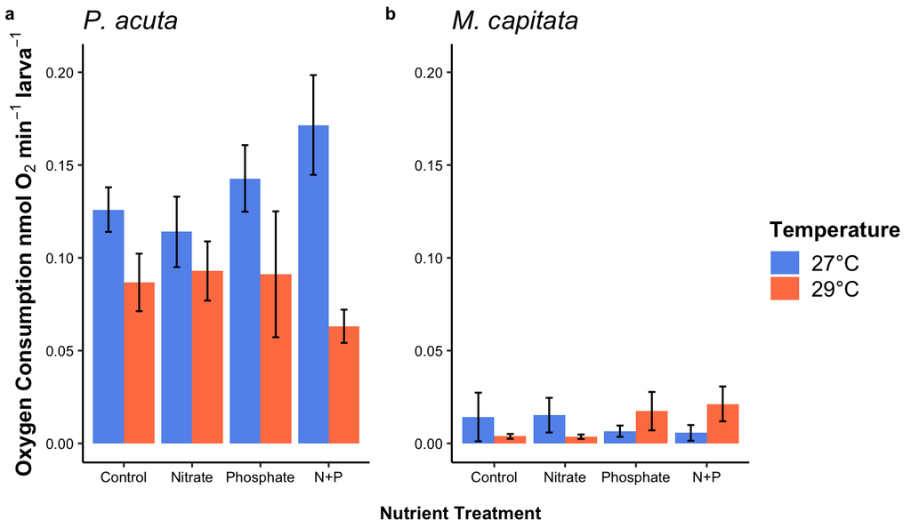

**Figure 4a-b**. Coral larva (a,b) dark respiration rates for Pocillopora acuta and Montipora capitata in response to orthogonal temperature and nutrient treatments. L. scutaria respiration rates were poorly resolved and larvae are aposymbiotic.

```r
####################### Combined Respiration Measurements ###########################################
###########################################################################################

resp.slopes=read.csv("Data/respiration slopes.csv")
resp.slopes$Nutrient.Treatment=factor(resp.slopes$Nutrient.Treatment,
                                      levels=c("Control", "Nitrate", "Phosphate", "N+P"))

p.resp=subset(resp.slopes, Species=="Pocillopora acuta")
m.resp=subset(resp.slopes, Species=="Montipora capitata")

library("plyr") # reload plyr

#####
#####
#### Figures

##### Pocillopora resp. plot
p.respiration=ddply(p.resp, c("Treatment", "Nutrient.Treatment", "Heat.Treatment"), summarise,
                    N    = length(nmol.min.larv.cons[!is.na(nmol.min.larv.cons)]),
                    mean = mean(nmol.min.larv.cons, na.rm=TRUE),
                    sd   = sd(nmol.min.larv.cons, na.rm=TRUE),
                    se   = sd / sqrt(N),
                    max = max(nmol.min.larv.cons, na.rm=TRUE))

p.resp.graph= ggplot(p.respiration, aes(x=Nutrient.Treatment, y=mean, fill=Heat.Treatment)) +
  scale_fill_manual(values = c("cornflowerblue","coral"), name="Temperature") +
  labs(x="", y=expression(bold(Oxygen~Consumption~nmol~O[2]~min^{-1}~larva^{-1}))) +
  geom_bar(position=position_dodge(), stat="identity") +
  geom_errorbar(aes(ymin=mean-se, ymax=mean+se),
                width=.2,
                position=position_dodge(.9))+
  theme_classic()+
  theme(legend.key.height=unit(0.5, "cm"),
        text = element_text(size = 12),
        axis.text = element_text(size = 8, color="black"),
        axis.title = element_text(size = 12, face="bold"),
        legend.title = element_text(size = 12, face="bold"),
        legend.text = element_text(size = 12, color="black"),
        legend.position="none")+
  ggtitle("P. acuta") +
  theme(plot.title= element_text(face="italic"))+
  coord_cartesian(ylim=c(0,0.205))


##### Montipora resp. plot
m.respiration=ddply(m.resp, c("Treatment", "Nutrient.Treatment", "Heat.Treatment"), summarise,
                    N    = length(nmol.min.larv.cons[!is.na(nmol.min.larv.cons)]),
                    mean = mean(nmol.min.larv.cons, na.rm=TRUE),
                    sd   = sd(nmol.min.larv.cons, na.rm=TRUE),
                    se   = sd / sqrt(N),
                    max = max(nmol.min.larv.cons, na.rm=TRUE))

##
m.resp.graph= ggplot(m.respiration, aes(x=Nutrient.Treatment, y=mean, fill=Heat.Treatment)) +
  scale_fill_manual(values = c("cornflowerblue","coral"), name="Temperature", labels = c("27°C", "29°C")) +
  labs(x="", y="") +
  geom_bar(position=position_dodge(), stat="identity") +
  geom_errorbar(aes(ymin=mean-se, ymax=mean+se),
                width=.2,
                position=position_dodge(.9))+
  theme_classic()+
 theme(legend.key.height=unit(0.5, "cm"),
        text = element_text(size = 12),
        axis.text = element_text(size = 8, color="black"),
        axis.title = element_text(size = 12, face="bold"),
        legend.title = element_text(size = 12, face="bold"),
        legend.text = element_text(size = 12, color="black"),
        legend.position="none")+
  ggtitle("M. capitata") +
  theme(plot.title= element_text(face="italic")) +
  coord_cartesian(ylim=c(0,0.205))



### Creating panelled figure
label="Nutrient Treatment"

resp.legend=get_legend(m.resp.graph+theme(legend.position = "right"))
resp.row=plot_grid(p.resp.graph, m.resp.graph, labels = c("a","b"), align = "h", nrow=1, label_size = 10) +
  draw_figure_label(label, position = "bottom", size = 10, fontface="bold")
c.resp.graph=plot_grid(resp.row, resp.legend, nrow=1, rel_widths = c(5,1))

c.resp.graph
dev.copy(pdf, "figures/combined.resp.pdf", width = 7, height = 4)
dev.off()
```

The full model testing and assumptions of statistical tests (output not shown).

```r
######Pocillopora respiration
p.resp.model=lm(nmol.min.larv~Heat.Treatment*Nutrient.Treatment, data=p.resp)
anova(p.resp.model)
shapiro.test(p.resp.model$residuals)
leveneTest(p.resp.model)

posthoc<-emmeans(p.resp.model, ~Heat.Treatment)
multcomp::cld(posthoc)


######Montipora respiration
m.resp.model=lm(nmol.min.larv~Heat.Treatment*Nutrient.Treatment, data=m.resp)
anova(m.resp.model)
shapiro.test(m.resp.model$residuals)
leveneTest(m.resp.model)
```

**The final models for for *P. acuta* and *M. capitata* respiration.**

```r
anova(p.resp.model)
```

```
## Analysis of Variance Table
##
## Response: nmol.min.larv
##                                   Df   Sum Sq   Mean Sq F value    Pr(>F)
## Heat.Treatment                     1 0.028053 0.0280532 15.1287 0.0005168
## Nutrient.Treatment                 3 0.001880 0.0006268  0.3380 0.7979434
## Heat.Treatment:Nutrient.Treatment  3 0.009848 0.0032828  1.7704 0.1740627
## Residuals                         30 0.055629 0.0018543
##
## Heat.Treatment                    ***
## Nutrient.Treatment
## Heat.Treatment:Nutrient.Treatment
## Residuals
## ---
## Signif. codes:  0 '***' 0.001 '**' 0.01 '*' 0.05 '.' 0.1 ' ' 1
```

```r
anova(m.resp.model)
```

```
## Analysis of Variance Table
##
## Response: nmol.min.larv
##                                   Df    Sum Sq    Mean Sq F value Pr(>F)
## Heat.Treatment                     1 0.0000125 0.00001246  0.0419 0.8391
## Nutrient.Treatment                 3 0.0001693 0.00005642  0.1899 0.9024
## Heat.Treatment:Nutrient.Treatment  3 0.0014289 0.00047630  1.6031 0.2094
## Residuals                         30 0.0089134 0.00029711
```

### Symbiont cells

First the figure, then models for *P. acuta* and *M. capitata*. Note that *L. scutaria* is not present here since larvae are aposymbiotic. First the figure, then the complete stats, then final models.

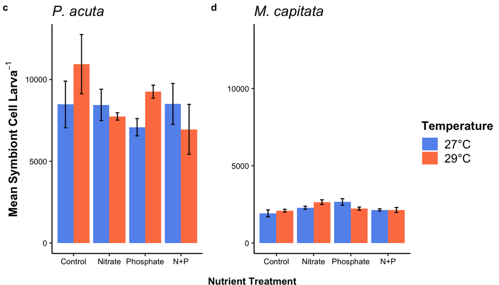

**Figure 4c-d**. Coral larva (c,d) symbiont cell densities for Pocillopora acuta and Montipora capitata in response to orthogonal temperature and nutrient treatments. L. scutaria respiration rates were poorly resolved and larvae are aposymbiotic.

```r
#############################################################################
############# Final Symbiont Count Figure ###################################
#############################################################################

c.cell.counts=read.csv("Data/symbiont density.csv")
c.cell.counts$Nutrient.Treatment=factor(c.cell.counts$Nutrient.Treatment,
                                        levels=c("none", "Control", "Nitrate", "Phosphate", "N+P"))

p.cell=subset(c.cell.counts, Species=="Pocillopora acuta")
m.cell=subset(c.cell.counts, Species=="Montipora capitata")

##### Figure dataframes
p.counts <- ddply(p.cell, c("Treatment", "Heat.Treatment", "Nutrient.Treatment"), summarise,
                  N    = length(Conc.per.larv[!is.na(Conc.per.larv)]),
                  mean = mean(Conc.per.larv, na.rm=TRUE),
                  sd   = sd(Conc.per.larv, na.rm=TRUE),
                  se   = sd / sqrt(N),
                  max = max(Conc.per.larv, na.rm=TRUE))

m.counts <- ddply(m.cell, c("Treatment", "Heat.Treatment", "Nutrient.Treatment"), summarise,
                  N    = length(Conc.per.larv[!is.na(Conc.per.larv)]),
                  mean = mean(Conc.per.larv, na.rm=TRUE),
                  sd   = sd(Conc.per.larv, na.rm=TRUE),
                  se   = sd / sqrt(N),
                  max = max(Conc.per.larv, na.rm=TRUE))


### Pocillopora cell density plot
p.counts.graph= ggplot(p.counts, aes(x=Nutrient.Treatment, y=mean, fill=Heat.Treatment)) +
  scale_fill_manual(values = c("cornflowerblue","coral"), name="Temperature") +
  labs(x="", y=expression(bold(Mean~Symbiont~Cell~Larva^{-1}))) +
  geom_bar(position=position_dodge(), stat="identity") +
  geom_errorbar(aes(ymin=mean-se, ymax=mean+se),
                width=.2,
                position=position_dodge(.9))+
  theme_classic()+
  theme(legend.key.height=unit(0.5, "cm"),
        text = element_text(size = 12),
        axis.text = element_text(size = 8, color="black"),
        axis.title = element_text(size = 12, face="bold"),
        legend.title = element_text(size = 12, face="bold"),
        legend.text = element_text(size = 12, color="black"),
        legend.position="none")+
  ggtitle("P. acuta") +
  theme(plot.title= element_text(face="italic"))
  coord_cartesian(ylim=c(0,13500))


### Montipora.cell density plot
m.counts.graph= ggplot(m.counts, aes(x=Nutrient.Treatment, y=mean, fill=Heat.Treatment)) +
  scale_fill_manual(values = c("cornflowerblue","coral"), name="Temperature", labels = c("27°C", "29°C")) +
  labs(x="", y="") +
  geom_bar(position=position_dodge(), stat="identity") +
  geom_errorbar(aes(ymin=mean-se, ymax=mean+se),
                width=.2,
                position=position_dodge(.9)) +
  coord_cartesian(ylim=c(0,13500)) +
  theme_classic()+
  theme(legend.key.height=unit(0.5, "cm"),
        text = element_text(size = 12),
        axis.text = element_text(size = 8, color="black"),
        axis.title = element_text(size = 12, face="bold"),
        legend.title = element_text(size = 12, face="bold"),
        legend.text = element_text(size = 12, color="black"),
        legend.position="none")+
  ggtitle("M. capitata") +
  theme(plot.title= element_text(face="italic"))

#### Arrange Graphs with cowplot
label="Nutrient Treatment"

counts.legend=get_legend(m.counts.graph+theme(legend.position = "right"))
counts.row=plot_grid(p.counts.graph, m.counts.graph, labels = c("c","d"), align = "h", nrow=1, label_size = 10) +
  draw_figure_label(label, position = "bottom", size = 10, fontface="bold")
counts.graph=plot_grid(counts.row, counts.legend, nrow=1, rel_widths = c(5,1))

counts.graph
dev.copy(pdf, "figures/combined.symbiont.counts.pdf", width = 8, height = 4)
dev.off()
```

The full model testing and assumptions of statistical tests (output not shown).

```r
### models
# Pocillopora

# p.cell is dataframe
p.count.model=lm(Conc.per.larv~Heat.Treatment*Nutrient.Treatment, data=p.cell)
anova(p.count.model)
shapiro.test(p.count.model$residuals)  #Not normal
leveneTest(p.count.model)

p.cell$log.conc.per.larv=log(p.cell$Conc.per.larv)
p.log.model=lm(log.conc.per.larv~Heat.Treatment*Nutrient.Treatment, data=p.cell)
anova(p.log.model)
shapiro.test(p.log.model$residuals)  #Normal after log transformation
leveneTest(p.log.model)

###### Montipora cell count
# m.cell is dataframe
m.count.model=lm(Conc.per.larv~Heat.Treatment*Nutrient.Treatment, data=m.cell)
anova(m.count.model)
shapiro.test(m.count.model$residuals)
leveneTest(m.count.model)
posthoc.m = emmeans(m.count.model, ~Nutrient.Treatment)
multcomp::cld(posthoc.m)
```

**For both *P. acuta* and *M. capitata*: the final models for symbiont density.**

```r
anova(p.log.model)
```

```
## Analysis of Variance Table
##
## Response: log.conc.per.larv
##                                   Df  Sum Sq  Mean Sq F value Pr(>F)
## Heat.Treatment                     1 0.07991 0.079915  1.2055 0.2847
## Nutrient.Treatment                 3 0.11360 0.037865  0.5712 0.6402
## Heat.Treatment:Nutrient.Treatment  3 0.28479 0.094929  1.4320 0.2616
## Residuals                         21 1.39215 0.066293
```

```r
anova(m.count.model)
```

```
## Analysis of Variance Table
##
## Response: Conc.per.larv
##                                   Df  Sum Sq Mean Sq F value  Pr(>F)
## Heat.Treatment                     1     991     991  0.0096 0.92245
## Nutrient.Treatment                 3 1457029  485676  4.7231 0.00814 **
## Heat.Treatment:Nutrient.Treatment  3  814138  271379  2.6391 0.06758 .
## Residuals                         30 3084887  102830
## ---
## Signif. codes:  0 '***' 0.001 '**' 0.01 '*' 0.05 '.' 0.1 ' ' 1
```

### Larval Size

The % change in larval size from the start to end of the experiment for all three species. First the figure, then the complete stats, then final models.

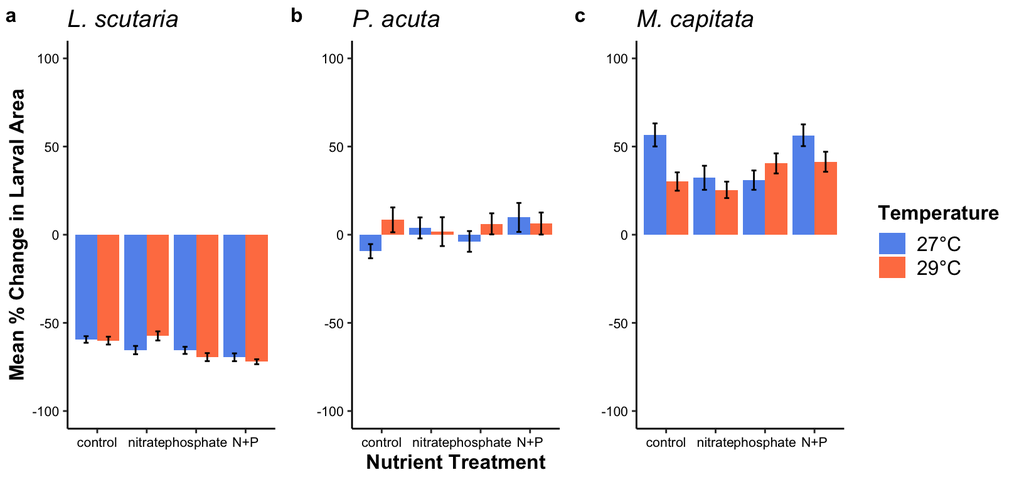

**Figure 5**. Percent change in larvae size in three coral species in response to orthogonal temperature and nutrient treatments.

```r
##############################################################################################
########################## Combined Size Comparison Figure ###################################
##############################################################################################

# Load data
combined.size=read.csv("data/larval size.csv")
combined.size$Area.micrometer=(combined.size$Area)*1000
combined.size$Percent.change=(((combined.size$Area.micrometer)/47.42105)-1)*100
combined.size=combined.size%>%select(Species, Treatment, Nutrient.Treatment, Heat.Treatment, Area.micrometer)

levels(combined.size$Nutrient.Treatment)[levels(combined.size$Nutrient.Treatment)==
                                           "nitrate and phosphate"] <- "N+P"
combined.size$Nutrient.Treatment=factor(combined.size$Nutrient.Treatment,
                                        levels=c("none", "control", "nitrate", "phosphate", "N+P"))

############
#Lobactis
lobactis.size=subset(combined.size, Species=="Lobactis scutaria")
lobactis.size$Percent.change=(((lobactis.size$Area.micrometer)/47.42105)-1)*100

lobactis.end=subset(lobactis.size, Treatment != "Day 0")
lobactis.end$real.percent=(((lobactis.end$Area.micrometer)/47.42105)-1)*100

#Pocillopora
pocillopora.size=subset(combined.size, Species=="Pocillopora acuta")
pocillopora.size$Percent.change=(((pocillopora.size$Area.micrometer)/843.9130435)-1)*100

pocillopora.end=subset(pocillopora.size, Treatment != "Day 0")
pocillopora.end$real.percent=(((pocillopora.end$Area.micrometer)/843.9130435)-1)*100


#Montipora
montipora.size=subset(combined.size, Species=="Montipora capitata")
montipora.size$Percent.change=(((montipora.size$Area.micrometer)/219)-1)*100

montipora.end=subset(montipora.size, Treatment != "Day 0")
montipora.end$real.percent=(((montipora.end$Area.micrometer)/219)-1)*100

#### Figures
l.size <- ddply(lobactis.end, c("Treatment", "Heat.Treatment", "Nutrient.Treatment"), summarise,
                N    = length(real.percent[!is.na(real.percent)]),
                mean = mean(real.percent, na.rm=TRUE),
                sd   = sd(real.percent, na.rm=TRUE),
                se   = sd / sqrt(N),
                max = max(real.percent, na.rm=TRUE))


l.size.graph= ggplot(l.size, aes(x=Nutrient.Treatment, y=mean, fill=Heat.Treatment)) +
  scale_fill_manual(values = c("cornflowerblue","coral"), name="Temperature", labels = c("27°C", "29°C")) +
  labs(x="", y="Mean % Change in Larval Area") +
  geom_bar(position=position_dodge(), stat="identity") +
  geom_errorbar(aes(ymin=mean-se, ymax=mean+se),
                width=.2,
                position=position_dodge(.9))+
  theme_classic()+
   theme(legend.key.height=unit(0.5, "cm"),
        text = element_text(size = 12),
        axis.text = element_text(size = 8, color="black"),
        axis.title = element_text(size = 12, face="bold"),
        legend.title = element_text(size = 12, face="bold"),
        legend.text = element_text(size = 12, color="black"),
        legend.position="none")+
  ggtitle("L. scutaria") +
  theme(plot.title= element_text(face="italic"))+
  coord_cartesian(ylim=c(-100,100))


#### Pocillopora
p.size<- ddply(pocillopora.end, c("Treatment", "Heat.Treatment", "Nutrient.Treatment"), summarise,
               N    = length(real.percent[!is.na(real.percent)]),
               mean = mean(real.percent, na.rm=TRUE),
               sd   = sd(real.percent, na.rm=TRUE),
               se   = sd / sqrt(N),
               max = max(real.percent, na.rm=TRUE))

p.size.graph= ggplot(p.size, aes(x=Nutrient.Treatment, y=mean, fill=Heat.Treatment)) +
  scale_fill_manual(values = c("cornflowerblue","coral"), name="Temperature") +
  labs(x="Nutrient Treatment", y="") +
  geom_bar(position=position_dodge(), stat="identity") +
  geom_errorbar(aes(ymin=mean-se, ymax=mean+se),
                width=.2,
                position=position_dodge(.9))+
  theme_classic()+
   theme(legend.key.height=unit(0.5, "cm"),
        text = element_text(size = 12),
        axis.text = element_text(size = 8, color="black"),
        axis.title = element_text(size = 12, face="bold"),
        legend.title = element_text(size = 12, face="bold"),
        legend.text = element_text(size = 12, color="black"),
        legend.position="none")+
  ggtitle("P. acuta") +
  theme(plot.title= element_text(face="italic"))+
  coord_cartesian(ylim=c(-100,100))


### Montipora
m.size<- ddply(montipora.end, c("Treatment", "Heat.Treatment", "Nutrient.Treatment"), summarise,
               N    = length(real.percent[!is.na(real.percent)]),
               mean = mean(real.percent, na.rm=TRUE),
               sd   = sd(real.percent, na.rm=TRUE),
               se   = sd / sqrt(N),
               max = max(real.percent, na.rm=TRUE))

m.size.graph= ggplot(m.size, aes(x=Nutrient.Treatment, y=mean, fill=Heat.Treatment)) +
  scale_fill_manual(values = c("cornflowerblue","coral"), name="Temperature") +
  labs(x="", y="") +
  geom_bar(position=position_dodge(), stat="identity") +
  geom_errorbar(aes(ymin=mean-se, ymax=mean+se),
                width=.2,
                position=position_dodge(.9))+
  theme_classic()+
   theme(legend.key.height=unit(0.5, "cm"),
        text = element_text(size = 12),
        axis.text = element_text(size = 8, color="black"),
        axis.title = element_text(size = 12, face="bold"),
        legend.title = element_text(size = 12, face="bold"),
        legend.text = element_text(size = 12, color="black"),
        legend.position="none")+
  ggtitle("M. capitata") +
  theme(plot.title= element_text(face="italic"))+
  coord_cartesian(ylim=c(-100,100))



#### plot
size.legend=get_legend(l.size.graph+theme(legend.position = "right"))
size.row=plot_grid(l.size.graph,p.size.graph, m.size.graph, labels = c("a","b","c"), align = "h", nrow=1, label_size=12)

##Combined panelled figure
plot_grid(size.row, size.legend, nrow=1, rel_widths = c(5,1))
```

```r
dev.copy(pdf, "figures/combined.size.pdf", width = 8, height = 4)
dev.off()
```

The full model testing and assumptions of statistical tests (output not shown).

```r
##### Statistics: change in size

kruskal.test(Percent.change ~ Heat.Treatment, data = lobactis.end) # no effect of temp
kruskal.test(Percent.change ~ Nutrient.Treatment, data = lobactis.end) # effect of nutrients
kruskal.test(Percent.change ~ Treatment, data = lobactis.end) # effect combined treatments

pairwise.wilcox.test(lobactis.end$Percent.change, lobactis.end$Treatment,
                     p.adjust.method = "BH", exact=FALSE)

l.DT1 = dunnTest(Percent.change ~ Treatment,
                 data=lobactis.end,
                 method="bh")
l.PT1 = l.DT1$res
cldList(P.adj ~ Comparison,
        data = l.PT1,
        threshold = 0.05)


###### Pocillopora size by treatment
kruskal.test(Percent.change ~ Heat.Treatment, data = pocillopora.end) # no effect
kruskal.test(Percent.change ~ Nutrient.Treatment, data = pocillopora.end) # no effect
kruskal.test(Percent.change ~ Treatment, data = pocillopora.end) # no effect

###### Montipora size by treatment

kruskal.test(Percent.change ~ Heat.Treatment, data = montipora.end) # effect (barely)
kruskal.test(Percent.change ~ Nutrient.Treatment, data = montipora.end) # effect
kruskal.test(Percent.change ~ Treatment, data = montipora.end) # effect

pairwise.wilcox.test(montipora.end$Percent.change, montipora.end$Treatment,
                     p.adjust.method = "BH", exact=FALSE)

m.DT1 = dunnTest(Percent.change ~ Treatment,
                 data=montipora.end,
                 method="bh")

m.PT1 = m.DT1$res
cldList(P.adj ~ Comparison,
        data = m.PT1,
        threshold = 0.05)
```

**For *L. scutaria*: final larval size models (1) Temperature, (2) Nutrients, (3) Temp x Nutr.**

```r
###### Lobactis size by treatment
kruskal.test(Percent.change ~ Heat.Treatment, data = lobactis.end) # no effect of temp
```

```
##
##  Kruskal-Wallis rank sum test
##
## data:  Percent.change by Heat.Treatment
## Kruskal-Wallis chi-squared = 0.16239, df = 1, p-value = 0.687
```

```r
kruskal.test(Percent.change ~ Nutrient.Treatment, data = lobactis.end) # effect of nutrients
```

```
##
##  Kruskal-Wallis rank sum test
##
## data:  Percent.change by Nutrient.Treatment
## Kruskal-Wallis chi-squared = 31.172, df = 3, p-value = 7.82e-07
```

```r
kruskal.test(Percent.change ~ Treatment, data = lobactis.end) # effect combined treatments
```

```
##
##  Kruskal-Wallis rank sum test
##
## data:  Percent.change by Treatment
## Kruskal-Wallis chi-squared = 37.82, df = 7, p-value = 3.279e-06
```

**For *P. acuta*: final larval size models (1) Temperature, (2) Nutrients, (3) Temp x Nutr.**

```r
###### Pocillopora size by treatment
kruskal.test(Percent.change ~ Heat.Treatment, data = pocillopora.end) # no effect
```

```
##
##  Kruskal-Wallis rank sum test
##
## data:  Percent.change by Heat.Treatment
## Kruskal-Wallis chi-squared = 2.4576, df = 1, p-value = 0.117
```

```r
kruskal.test(Percent.change ~ Nutrient.Treatment, data = pocillopora.end) # no effect
```

```
##
##  Kruskal-Wallis rank sum test
##
## data:  Percent.change by Nutrient.Treatment
## Kruskal-Wallis chi-squared = 2.327, df = 3, p-value = 0.5074
```

```r
kruskal.test(Percent.change ~ Treatment, data = pocillopora.end) # no effect
```

```
##
##  Kruskal-Wallis rank sum test
##
## data:  Percent.change by Treatment
## Kruskal-Wallis chi-squared = 9.9619, df = 7, p-value = 0.1907
```

**For *M. capitata*: final larval size models (1) Temperature, (2) Nutrients, (3) Temp x Nutr.**

```r
###### Montipora size by treatment
kruskal.test(Percent.change ~ Heat.Treatment, data = montipora.end) # effect (barely)
```

```
##
##  Kruskal-Wallis rank sum test
##
## data:  Percent.change by Heat.Treatment
## Kruskal-Wallis chi-squared = 6.4447, df = 1, p-value = 0.01113
```

```r
kruskal.test(Percent.change ~ Nutrient.Treatment, data = montipora.end) # effect
```

```
##
##  Kruskal-Wallis rank sum test
##
## data:  Percent.change by Nutrient.Treatment
## Kruskal-Wallis chi-squared = 15.071, df = 3, p-value = 0.001757
```

```r
kruskal.test(Percent.change ~ Treatment, data = montipora.end) # effect
```

```
##
##  Kruskal-Wallis rank sum test
##
## data:  Percent.change by Treatment
## Kruskal-Wallis chi-squared = 31.15, df = 7, p-value = 5.835e-05
```